# Лабораторная работа №6

Репкина Елизавета Андреевна

1132246753@rudn.ru

Российский университет дружбы народов

# Информация

## Докладчик

- Репкина Елизавета Андреевна
- Российский университет дружбы народов им. П. Лумумбы

## Цели и задачи

Развить навыки администрирования ОС Linux. Получить первое практическое знакомство с технологией SELinux1. Проверить работу SELinx на практике совместно с веб-сервером Apache.

# Ход работы

## 1

Вхожу в систему с полученными учётными данными и убеждаюсь, что SELinux работает в режиме enforcing политики targeted с помощью команд getenforce и sestatus.(рис. 1)

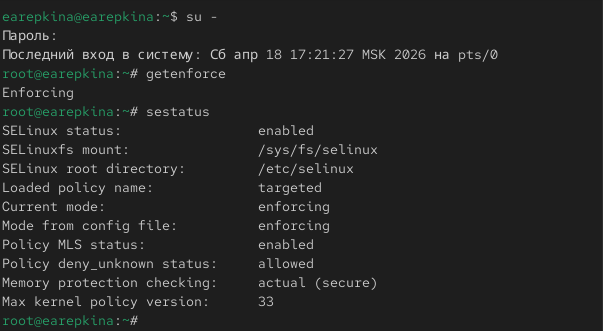

Рисунок 1: Правильный вывод

## 2

Выполняю команду service httpd status (рис. 2)

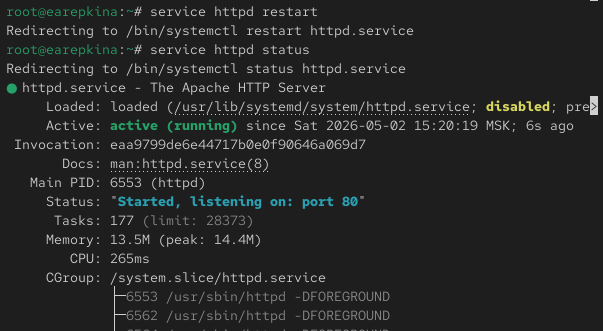

Рисунок 2: Запуск

## 3

Нахожу веб-сервер Apache в списке процессов, определяю его контекст безопасности .(рис. 3)

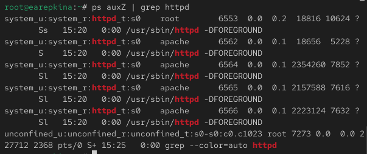

Рисунок 3: Команда ps auxZ | grep httpd

## 4

Смотрю статистику по политике с помощью команды seinfo, также определяю множество пользователей, ролей, типов.(рис. 4)

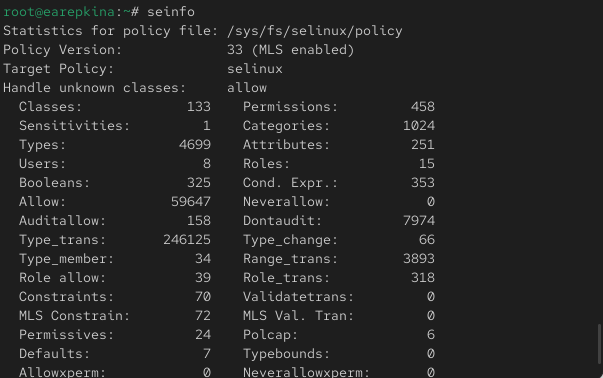

Рисунок 4: Запуск seinfo

## 5

Определяю типы файлов и поддиректорий (рис. 5)

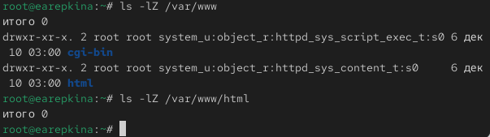

Рисунок 5: Запуск команд

## 6

Создаю от имени суперпользователя (так как в дистрибутиве после установки только ему разрешена запись в директорию) html-файл /var/www/html/test.html следующего содержания:(рис. 6)

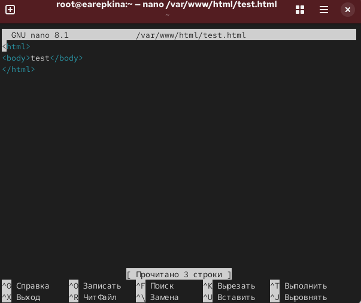

Рисунок 6: Содержание файла

## 7

Обращаюсь к файлу через веб-сервер, введя в браузере адрес http://127.0.0.1/test.html. Убеждаюсь, что файл был успешно отображён.(рис. 7)

[figure not shown]

Рисунок 7: Переход по ссылке

## 8

Изучаю справку man httpd_selinux и выясняю, какие контексты файлов определены для httpd. Сопоставляю их с типом файла test.html.(рис. 8)

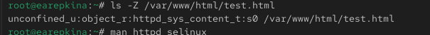

Рисунок 8: Запуск команды

## 9

Измените контекст файла /var/www/html/test.html с httpd_sys_content_t на любой другой, к которому процесс httpd не должен иметь доступа, например, на samba_share_t: (рис. 9)

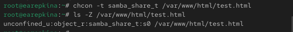

Рисунок 9: Изменение

## 10

Пробую ещё раз получить доступ к файлу через веб-сервер, введя в браузере адрес http://127.0.0.1/test.html. Получаю сообщение об ошибке(рис. 10)

[figure not shown]

Рисунок 10: ошибка

## 11

Анализирую ситуацию и просмотриваю log-файлы веб-сервера Apache. Также просматриваю системный лог-файл (рис. 11)

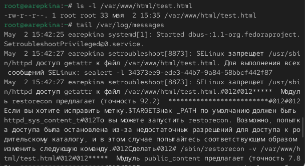

Рисунок 11: Просмотр

## 12

Запускаю веб-сервер Apache на прослушивание ТСР-порта 81 (а не 80, как рекомендует IANA и прописано в /etc/services)(рис. 12)

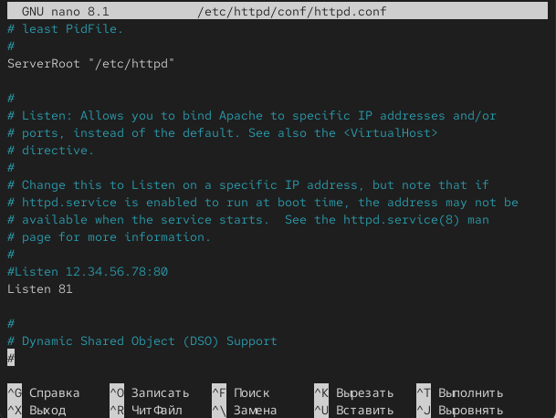

Рисунок 12: Изменение 80 на 81

## 13

перезапускаю и просматриваю файлы(рис. 13)

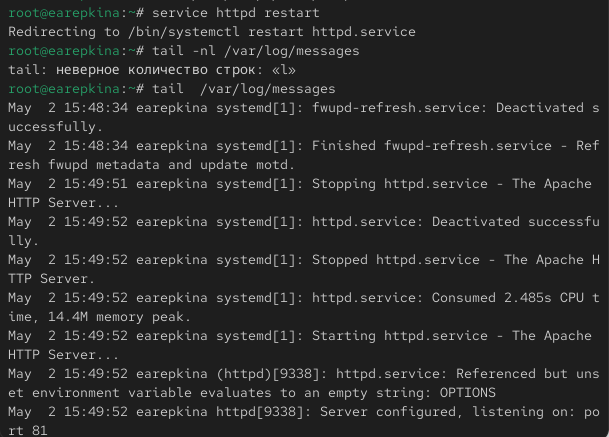

Рисунок 13: перезапуск

## 14

Выполняю команды (рис. 14)

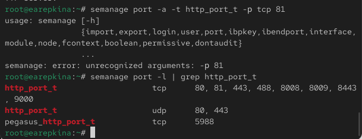

Рисунок 14: Выполнение

## 15

Возвращаю контекст httpd_sys_cоntent__t к файлу /var/www/html/ test.html: chcon -t httpd_sys_content_t /var/www/html/test.html После этого пробую получить доступ к файлу через веб-сервер, введя в браузере адрес http://127.0.0.1:81/test.html. содержимое файла — слово «test»(рис. 15)

[figure not shown]

Рисунок 15: Слово test

## 16

Исправляю обратно конфигурационный файл apache, вернув Listen 80 и удаляю файл(рис. 16)

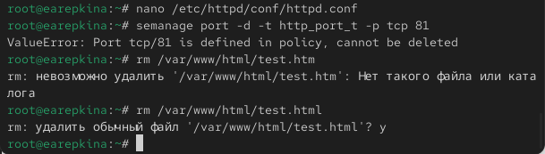

Рисунок 16: Удаление

## Выводы

В ходе выполнения лабораторной работы я развила навыки администрирования ОС Linux. Получила первое практическое знакомство с технологией SELinux1. Проверила работу SELinx на практике совместно с веб-сервером Apache.